[figure not shown]

# Методы машинного обучения

### Шестаков Андрей (avshestakov@hse.ru)

## Линейные модели классификации. Методы понижения размерности

# Логистическая регрессия

## aka logit model

[figure not shown]

Нам надо найти уравнение прямой (гиперплоскости), которая бы могла разделить два класса ($H_2$ и $H_3$ подходят). В данном случае, уравнение прямой задаётся как: $$g(x) = w_0 + w_1x_1 + w_2x_2 = \langle w, x \rangle + w_0 = w^\top x + w_0$$

- Если $g(x^*) > 0$, то $y^* = \text{'черный'} = +1$
- Если $g(x^*) < 0$, то $y^* = \text{'белый'} = -1$
- Если $g(x^*) = 0$, то мы находимся на линии

Перед тем как мы начнем, рассмотрим функцию $$\sigma(z) = \frac{1}{1 + exp{(-z)}},$$она называется **сигмойда**.

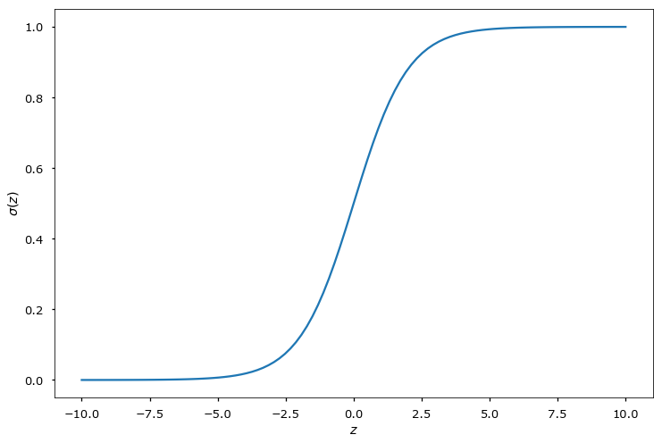

```python
def sigmoid(z):
    return 1./(1+np.exp(-z))
demo_sigmoid()
```

[figure not shown]

#### Постановка задачи

Будем требовать, чтобы алгоритм возвращал вероятность класса $y=+1$: $$h(x,w) = p(y=+1|x,w) = \sigma(g(x))$$

Выпишем функцию правдоподобия $$ \mathcal{L}(w) = \prod_i^n h(x^{(i)},w)^{[y^{(i)} = +1]} (1 - h(x^{(i)},w))^{[y^{(i)} = -1]} \rightarrow \max_w$$ $$ -\log{\mathcal{L}(w)} = - \sum_i^n [y^{(i)} = +1]\cdot\log{(h(x^{(i)},w))} + {[y^{(i)} = -1]}\cdot\log{(1-h(x^{(i)},w))} \rightarrow \min_w$$ $$L(w) = \log{\mathcal{L}(w)} \rightarrow \min_w $$

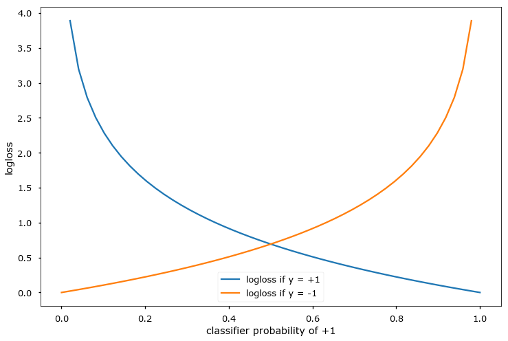

```python
logloss_demo()
```

Рассмотрим объекты со следующими признаками:

| x1 | x2 |
| --- | --- |
| 0 | 1 |
| 1 | 0 |
| 1 | 1 |
| 2 | 2 |
| 2 | 3 |
| 3 | 2 |

Определите к какому классу относятся наблюдения, если вектор параметров имеет вид $(w_0 = -0.3 , w_1 = 0.1, w_2 = 0.1)$

```python
X = np.array([[0,1],[1,0],[1,1],[2,2],[2,3],[3,2]])
w = np.array([.1, .1])
w0 = -.3

sigmoid(X.dot(w) + w0)
```

```
array([0.450166  , 0.450166  , 0.47502081, 0.52497919, 0.549834  ,
       0.549834  ])
```

## Другая постановка

## Вспоминаем

$$g(x) = w_0 + w_1x_1 + w_2x_2 = \langle w, x \rangle + w_0 = w^\top x + w_0$$

- Если $g(x^*) > 0$, то $y^* = \text{'черный'} = +1$
- Если $g(x^*) < 0$, то $y^* = \text{'белый'} = -1$
- Если $g(x^*) = 0$, то мы находимся на линии
- т.е. решающее правило: $y^* = sign(g(x^*))$

Величину $M_i = y^{(i)} \cdot g(x^{(i)})$ называют **отступом**(margin)

Если для какого-то объекта $M_i \geq 0$, то его классификация выполнена успешно.

[figure not shown]

Отлично! Значит нам надо просто минимизировать ошибки классификации для всех объектов:

$$L(w) = \sum_i [y^{(i)} g(x^{(i)}) < 0] \rightarrow \min_w$$

Проблема в том, что это будет комбинаторная оптимизация. Существуют различные аппроксимации этой функции ошибок:

[figure not shown]

#### Другая постановка

Рассмотрим принадлежность к классу $y=\pm1$ некого объекта $x$: $$p(y=\pm1 | x,w)$$ и выразим её через **сигмойду** от **отступа**:

$$p(y=\pm1|x,w) = \sigma(y (\langle w, x \rangle + w_0)) = \sigma(y^{(i)} g(x^{(i)}))$$

А ошибка, которую мы будем минимизировать - логарифмическая:

$$L(w) = - \frac{1}{N}\sum_i \log(\sigma(y^{(i)} g(x^{(i)})) = \frac{1}{N}\sum_i \log(1 + e^{-y^{(i)} g(x^{(i)})}) \rightarrow \min_w$$

[figure not shown]

- Как искать $w$? - c помощью градиентного спуска!
- А что с регуляризацией? - та же история
  - Lasso: $ \frac{1}{C} \sum\limits_{j=1}^d |w_j|$
  - Rigde: $ \frac{1}{C} \sum\limits_{j=1}^d w_j^2$

## Многоклассовая классификация

- А если классов несколько?
  - 1-vs-1
  - 1-vs-rest
  - Softmax

[figure not shown]

## Softmax

Для каждого класса определяется свой набор весов $$ \begin{cases} g_1(x)=w_{1}^{T}x + w_{0,1} \\ g_{2}(x)=w_{2}^{T}x + w_{0,2}\\ \cdots\\ g_{C}(x)=w_{C}^{T}x + + w_{0,C} \end{cases} $$

Нормировка "скоров" классов

$$ p(y=c|x)=softmax(g_c|W, x)=\frac{exp(w_{c}^{T}x + w_{0,c})}{\sum_{i}exp(w_{i}^{T}x + w_{0,i})} $$

# Методы понижения размерности признаков

[figure not shown]

## Проклятье размености

[figure not shown]

## Проклятье размерности

[output not shown]

$$ \lim_{d \rightarrow \infty} \frac{\text{dist}_{max} - \text{dist}_{min}}{\text{dist}_{min}} = 0$$

## Для чего можно понижать размерность признаков?

- Cмотреть на 2-3 признака удобнее чем на 100
- Потенциально может улучшить качество моделей
- Удаление лишних коррелирующих признаков
- Ускоряет обучение
- Данные занимают меньше места
- Меньше признаков - легче интерпретировать модели

## Способы понижения размерности

Избавляться от размерности можно методами **отбора признаков (Feature Selection)** и методами **уменьшения размерности (Feature Reduction)**

**Глобальная разница**

- Feature Selection: не используем часть признаков
- Feature Reduction: исходные признаки проходят через некоторое преобразование $f(\cdot)$, и на выходе признаков становится меньше

### Feature Selection

Методы деляться на следующие группы:

- **Unsupervised methods**
  - Определяем полезность признака вне зависимости от целевой переменной
- **Filter methods**
  - Признаки рассматриваются независимо друг от друга
  - Изучается индивидуальный "вклад" призника в предсказываемую переменную
  - Быстрое вычисление
  - *Пример?*
- **Wrapper methods**
  - Идет отбор группы признаков
  - Может быть оооочень медленным, но качество, обычно, лучше чем у Filter Methods
  - Примеры: Stepwise feature selection for regression, Boruta Algorithm
- **Embedded methods**
  - Отбор признаков "зашит" в модель

#### Filter method - Mutual Information

$$MI(y,x) = \sum_{x,y} p(x,y) \ln\left[\frac{p(x,y)}{p(x)p(y)}\right]$$

Сколько информации $x$ сообщает об $y$.

```python
df_titanic = pd.read_csv('titanic.csv')
df_titanic.head()
```

|  | PassengerId | Survived | Pclass | Name | Sex | Age | SibSp | Parch | Ticket | Fare | Cabin | Embarked |
| --- | --- | --- | --- | --- | --- | --- | --- | --- | --- | --- | --- | --- |
| 0 | 1 | 0 | 3 | Braund, Mr. Owen Harris | male | 22.0 | 1 | 0 | A/5 21171 | 7.2500 | NaN | S |
| 1 | 2 | 1 | 1 | Cumings, Mrs. John Bradley (Florence Briggs Th... | female | 38.0 | 1 | 0 | PC 17599 | 71.2833 | C85 | C |
| 2 | 3 | 1 | 3 | Heikkinen, Miss. Laina | female | 26.0 | 0 | 0 | STON/O2. 3101282 | 7.9250 | NaN | S |
| 3 | 4 | 1 | 1 | Futrelle, Mrs. Jacques Heath (Lily May Peel) | female | 35.0 | 1 | 0 | 113803 | 53.1000 | C123 | S |
| 4 | 5 | 0 | 3 | Allen, Mr. William Henry | male | 35.0 | 0 | 0 | 373450 | 8.0500 | NaN | S |

```python
from sklearn.metrics import mutual_info_score
pd.crosstab(df_titanic.Survived, df_titanic.Sex, normalize=True)

mutual_info_score(df_titanic.Survived.values,
                  df_titanic.Sex.values)
```

```
0.15087048925218183
```

#### Wrapper Methods - Recursive Feature Elimination

При данном подходе из линейной модели последовательно удаляются признаки с наименьшим коэффициентом

# Principal Component Analysis

## Метод Главных Компонент

## Интерпретация

- Интерпретация 1: находит такие ортогональные оси, вдоль которых дисперсия данных максимальна

[figure not shown]

## Интерпретация

- Интерпретация 2: Найти такое подпространство меньшей размерности $L$ Такое что различие между точками и их проекциями минимальна

[figure not shown]

## В двух словах:

- Совершаем переход к новым осям, так что:
  - Новые переменные являются линейной комбинацией старых переменных
  - Новые оси ортогональны друг другу
  - Дисперсия вдоль новых осей максимальная

## Что значит "перейти к новым координатам"?

- Пусть у нас есть объект $x$ с тремя признаками: $x=(-0.343, -0.754, 0.241)$
- Можно сказать, что он представлен в пространстве, натянутом на 3 стандартных базистых вектора: $$ e_1 = \left( \begin{array}{c} 1 \\ 0 \\ 0 \end{array} \right) \quad e_2 = \left( \begin{array}{c} 0 \\ 1 \\ 0 \end{array} \right) \quad e_3 = \left( \begin{array}{c} 0 \\ 0 \\ 1 \end{array} \right) \quad$$

$$ x = -0.343 e_1 + -0.754 e_2 + 0.241 e_3 $$

- Предположими мы хотим перейти к другому базису, например:

$$ w_1 = \left( \begin{array}{c} -0.390 \\ 0.089 \\ -0.916 \end{array} \right) \quad w_2 = \left( \begin{array}{c} -0.639 \\ -0.742 \\ 0.200 \end{array} \right) \quad w_3 = \left( \begin{array}{c} -0.663 \\ 0.664 \\ 0.346 \end{array} \right) \quad$$

- Как спроицировать наш объект $x$ из исходного базиса в данный?

## Проецируем

(Пример взят из [Mohammed J. Zaki, Ch7](https://www.amazon.com/Data-Mining-Analysis-Fundamental-Algorithms/dp/0521766338) )

# Находим главные компоненты

- Новые оси ортогональны друг другу: $$\langle w_{i},w_{j}\rangle=\begin{cases} 1, & i=j\\ 0 & i\ne j \end{cases}$$
- Дисперсия вдоль новых осей максимальна
  - Предполагаем, что исходные признаки **центрированы** (и **шкалированы**) $$ \begin{align} \sigma^2_w & = \frac{1}{n}\sum\limits_{i=1}^n(z_i - \mu_z)^2 \\ & = \frac{1}{n}\sum\limits_{i=1}^n(w^\top x_i)^2 \\ & = \frac{1}{n}\sum\limits_{i=1}^n w^\top( x_i x_i^\top) w \\ & = w^\top \left(\frac{1}{n}\sum\limits_{i=1}^n x_i x_i^\top \right) w \\ & = w^\top C w \rightarrow \max_w \\ \end{align} $$
- $C = X^\top X$ - ковариационная матрица
- [Interpreting Covariance Matrix](http://www.visiondummy.com/2014/04/geometric-interpretation-covariance-matrix/)

# Находим главные компоненты

То есть, чтобы найти первую главную компоненту, надо решить такую задачу: $$ \begin{equation} \begin{cases} w_1^\top X^\top X w_1 \rightarrow \max_{w_1} \\ w_1^\top w_1 = 1 \end{cases} \end{equation} $$

## Решение для первой компоненты

Изначально было так $$ w_1^\top X^\top X w_1 \rightarrow \max_{w_1}$$

- Строим лагранжиан $$ \mathcal{L}(w_1, \nu) = w_1^\top X^\top X w_1 - \nu (w_1^\top w_1 - 1) \rightarrow max_{w_1, \nu}$$
- Считем производную по $w_1$ $$ \frac{\partial\mathcal{L}}{\partial w_1} = X^\top X w_1 - \nu w_1 = 0 \Leftrightarrow X^\top X w_1 = \nu w_1$$

Подставим одно в другое: $$ w_1^\top X^\top X w_1 = \nu w_1^\top w_1 = \nu \rightarrow \max$$

## Задача о собственном векторе, собственном числе матрицы

Пусть для матрицы $A$ существует ненулевой вектор $v$ и число $\lambda$ такие, что $$Av=\lambda v$$ Тогда вектор $v$ называют *собственным вектором* оператора $A$, а число $\lambda$ - соответствующим *собственным числом* оператора $A$.

Оказывается, что у матрицы ковариций $X^\top X$:

- Все собственные числа $\lambda_i \in \mathbb{R}, \lambda_i \geq 0$ (упорядочим индексы по возрастанию так, что $\lambda_1 \geq \lambda_2 \geq \dots \geq \lambda_d $)
- Собственные вектора при $\lambda_i \neq \lambda_j $ ортогональны: $v_i^\top v_j = 0$
- Для уникальных $\lambda_i$ уникальны и $v_i$

## Решение для первой компоненты

Изначально было так $$ w_1^\top X^\top X w_1 \rightarrow \max_{w_1}$$

- Строим лагранжиан $$ \mathcal{L}(w_1, \nu) = w_1^\top X^\top X w_1 - \nu (w_1^\top w_1 - 1) \rightarrow max_{w_1, \nu}$$
- Считем производную по $w_1$ $$ \frac{\partial\mathcal{L}}{\partial w_1} = X^\top X w_1 - \nu w_1 = 0 \Leftrightarrow X^\top X w_1 = \nu w_1$$

Подставим одно в другое: $$ w_1^\top X^\top X w_1 = \nu w_1^\top w_1 = \nu \rightarrow \max$$

Что значит, что:

- $\nu$ - наибольшее собственное число матрицы $X^\top X$, а именно - $\lambda_1$
- $w_1$ - собственный вектор при $\lambda_1$

## Задача и решение для второй компоненты

$$ \begin{equation} \begin{cases} w_2^\top X^\top X w_2 \rightarrow \max_{w_2} \\ w_2^\top w_2 = 1 \\ w_2^\top w_1 = 0 \end{cases} \end{equation} $$

Аналогичными операциями мы прийдем к тому, что $w_2$ - собственный вектор при втором по величине собственном числе матрицы $X^\top X$.

То есть поиск главных компонент сводится к поиску собственных векторов и собственных чисел матрицы $X^\top X$!

## Алгоритм

1. Центрируем и шкалируем исходные признаки
2. Считаем матрицу ковариаций $X^\top X$
3. Находим $k$ главных компонент и собственных чисел $$W = \left[ \begin{array}{cccc} \mid & \mid & & \mid\\ w_{1} & w_{2} & \ldots & w_{k} \\ \mid & \mid & & \mid \end{array} \right] $$
4. Проецируем на них: $$ Z = XW $$

## Сколько компонент брать или зачем нужны $\lambda$?

- Из предыдущих слайдов мы помним, что $$w_1^\top X^\top X w_1 = \lambda_1$$ То есть $\lambda_1$ равна дисперсии точек, спроецированных на первую базовую компоненту
- Величина $$ \frac{\lambda_{i}}{\sum_{d=1}^{D}\lambda_{d}} $$ Показывает долю объясненной дисперии компоненты $i$

[figure not shown]

## MNIST, DIGITS

[figure not shown]

## MNIST PCA

[figure not shown]

## Резюме

- PCA понижает размерность признакового пространства
- Новые компоненты являются линейной комбинацией исходных признаков
- Новые компоненты (не признаки) - ортогональны
- Можно применять в моделях и для визуализации
- [Tutorial 1](http://www.visiondummy.com/2014/05/feature-extraction-using-pca/)
- [PCA SVD туториал](https://www.cs.princeton.edu/picasso/mats/PCA-Tutorial-Intuition_jp.pdf)

# Многомерное шкалирование

## Идея

- Перейти в пространство меньшей размерности так, чтобы расстояния между объектами в новом пространстве были подобны расстояниям в исходном пространстве.
- Дано $X = [x_1,\dots, x_n]\in \mathbb{R}^{N \times D}$ и/или $\delta_{ij}$ - мера близости между $(x_i,x_j)$
- Надо найти $Y = [y_1,\dots,y_n] \in \mathbb{R}^{N \times d}$ такие, что $\delta_{ij} \approx d(y_i, y_j) = \|y_i-y_j\|^2$

[figure not shown]

Понятно, что точно воспроизвести расстояния получится не всегда

[figure not shown]

### Подходы

- Классический (cMDS)
- Метрический (metric MDS)
- Неметрический (non-metric MDS)

# t-SNE

## t-distributed stochastic neighbor embedding

- t-SNE - практически многомерное шкалирование
- Вместо этого мы будем пытаться перенести "окрестность" точек из исходного пространства в пространоство меньшей размерности
- Полученные расстояния скорее всего не будут соотносится с исходными
- Схожесть между объектами в исходном пространстве $\mathbb{R}^m$ $$ p(i, j) = \frac{p(i | j) + p(j | i)}{2n}, \quad p(j | i) = \frac{\exp(-\|\mathbf{x}_j-\mathbf{x}_i\|^2/{2 \sigma_i^2})}{\sum_{k \neq i}\exp(-\|\mathbf{x}_k-\mathbf{x}_i\|^2/{2 \sigma_i^2})} $$ $\sigma_i$ неявно задается пользователем
- Схожесть между объектами в целевом пространстве $\mathbb{R}^k, k << m$ $$ q(i, j) = \frac{g(|\mathbf{y}_i - \mathbf{y}_j|)}{\sum_{k \neq l} g(|\mathbf{y}_i - \mathbf{y}_j|)} $$ где $g(z) = \frac{1}{1 + z^2}$ - распределение Коши (t-распределение Стьюдента с 1 степенью свободы)
- Критерий $$ J_{t-SNE}(y) = KL(P \| Q) = \sum_i \sum_j p(i, j) \log \frac{p(i, j)}{q(i, j)} \rightarrow \min\limits_{\mathbf{y}} $$

## Дивергенция Кульбака-Лейблера

- Насколько распределение $P$ отличается от распределения $Q$? $$ KL(P \| Q) = \sum_z P(z) \log \frac{P(z)}{Q(z)} $$

[figure not shown]

## Оптимизация

- Оптимизируем $J_{t-SNE}(y)$ с помощью градиентного спуска

$$\frac{\partial J_{t-SNE}}{\partial y_i}=4 \sum_j(p(i,j)−q(i,j))(y_i−y_j)g(|y_i−y_j|)$$

- [Статья](http://jmlr.csail.mit.edu/papers/volume9/vandermaaten08a/vandermaaten08a.pdf)
- [Примеры](http://lvdmaaten.github.io/tsne/)
- [Демо и советы](http://distill.pub/2016/misread-tsne/)
  - t-SNE может быть нестабильным
  - Размеры полученных сгустков могут ничего не значить
  - Расстояния между кластерами могут ничего не значить
  - Полностью шумовые данные могут выдать структуру

[figure not shown]

# Литература

- [Mohammed J. Zaki, Ch7](https://www.amazon.com/Data-Mining-Analysis-Fundamental-Algorithms/dp/0521766338)
- [Мodern MDS](http://www.springer.com/la/book/9780387251509)
- [Habrahabr](https://habrahabr.ru/post/267041/)